# Scoring - Dimentionality Reduction - Linear Regression - Logistic Regression - Multimodal Logistic Regression

```r
AllAccidents_population$obs[which( is.na (AllAccidents_population$obs) |  AllAccidents_population$obs=="" )]<-"00"
summary(AllAccidents_population$circ)
```

```
##               0       1       2       3       4
##    1695   85963  284483 1082174  243156    9989
```

```r
AllAccidents_population$circ[which( is.na (AllAccidents_population$circ) |  AllAccidents_population$circ=="" )]<-"0"
AllAccidents_population$nbv<-as.numeric(as.character(AllAccidents_population$nbv))
summary(AllAccidents_population$nbv)
```

```
##    Min. 1st Qu.  Median    Mean 3rd Qu.    Max.    NA's
##   0.000   2.000   2.000   2.077   2.000  99.000    3924
```

```r
AllAccidents_population$nbv[which( is.na (AllAccidents_population$nbv) |  AllAccidents_population$nbv=="" )]<-"0"
AllAccidents_population$nbv<-as.numeric(as.character(AllAccidents_population$nbv))
AllAccidents_population$nbv[which( is.na (AllAccidents_population$nbv)  )]<-0
AllAccidents_population$nbv[which(  AllAccidents_population$nbv>8  )]<-8
summary(AllAccidents_population$vosp)
```

```
##               0       1       2       3
##    3632 1598256   33665   23832   48075
```

```r
AllAccidents_population$vosp[which( is.na (AllAccidents_population$vosp) |  AllAccidents_population$vosp=="" )]<-"0"
summary(AllAccidents_population$prof)
```

```
##               0       1       2       3       4
##    2298  129504 1291276  228334   32719   23329
```

```r
AllAccidents_population$prof[which( is.na (AllAccidents_population$prof) |  AllAccidents_population$prof=="" )]<-"0"
summary(AllAccidents_population$plan)
```

```
##               0       1       2       3       4
##    2339  109415 1317798  130997  125495   21416
```

```r
AllAccidents_population$larrout<-as.numeric(as.character(AllAccidents_population$larrout))
AllAccidents_population$plan[which( is.na (AllAccidents_population$plan) |  AllAccidents_population$plan=="" )]<-"0"

summary(AllAccidents_population$larrout)
```

```
##    Min. 1st Qu.  Median    Mean 3rd Qu.    Max.    NA's
##  -81.00    0.00   60.00   60.27   80.00  999.00   18107
```

```r
AllAccidents_population$larrout[which( is.na (AllAccidents_population$larrout) |  AllAccidents_population$larrout=="" )]<-"0"
AllAccidents_population$larrout<-as.numeric(as.character(AllAccidents_population$larrout))
AllAccidents_population$larrout[which(AllAccidents_population$larrout>74 )]<-74
AllAccidents_population$larrout[which(AllAccidents_population$larrout<0 )]<-mean(AllAccidents_population$larrout[!which(AllAccidents_population$larrout<0 )])
AllAccidents_population$larrout[which( is.na (AllAccidents_population$larrout) )]<-mean(AllAccidents_population$larrout[!is.na (AllAccidents_population$larrout)])

summary(AllAccidents_population$lartpc)
```

```
##     000     015     010     020             030     025     060     005
## 1393340   68113   41464   36138   21004   18708   13260    7433    7216
##     050     040     035     100     070     080     012     008     024
##    6904    6651    5395    4979    4876    3054    2950    2529    1884
##     018     011     006     120     028     016     065     026     090
##    1725    1609    1512    1402    1349    1322    1276    1272    1267
##     014     045     013     022     007     150     023     019     021
##    1238    1237    1202    1153    1147    1100    1078    1029    1029
##     200     001     075     032     017     027     003     009     055
##    1007     983     945     943     910     882     851     833     785
##     034     062     072     029     031     002     036     004     033
##     745     729     723     721     679     678     678     675     666
##     038     110     068     063     064     105     061     140     037
##     660     652     608     561     538     516     507     501     475
##     056     058     048     052     042     067     073     074     054
##     471     471     470     468     462     453     447     436     434
##     057     066     046     047     071     041     076     043     078
##     424     422     419     408     407     403     389     388     358
##     039     044     053     069     059     051     130     300     049
##     345     343     339     339     337     322     319     318     310
##     250     180     160     077     085     095     079     082     500
##     284     279     277     267     267     247     207     196     169
## (Other)
##    6269
```

```r
AllAccidents_population$lartpc[which( is.na (AllAccidents_population$lartpc) |  AllAccidents_population$lartpc=="" )]<-"0"
AllAccidents_population$lartpc<-as.numeric(as.character(AllAccidents_population$lartpc))
AllAccidents_population$lartpc[which(AllAccidents_population$lartpc>10 )]<-10
AllAccidents_population$lartpc[which( is.na (AllAccidents_population$lartpc) )]<-mean(AllAccidents_population$lartpc[!is.na (AllAccidents_population$lartpc)])

summary(AllAccidents_population$infra)
```

```
##               0       1       2       3       4       5       6       7
##    2794 1503813   14785   25273   27446    6639  114930   10236    1544
```

```r
AllAccidents_population$infra[which( is.na (AllAccidents_population$infra) |  AllAccidents_population$infra=="" )]<-"0"
summary(AllAccidents_population$situ)
```

```
##               0       1       2       3       4       5
##    2192   83205 1500667   10767   77350   23732    9547
```

```r
AllAccidents_population$situ[which( is.na (AllAccidents_population$situ) |  AllAccidents_population$situ=="" )]<-"0"


AllAccidents_population<-AllAccidents_population[ , !(names(AllAccidents_population) %in%   c("pop_2014") )]
```

Many values are qualitative and multimodal. We don’t want that. We’ll turn those into dummies with one-hot encoding

```r
NotDummies=c("nbv", "lartpc", "larrout","age","pop_avg")
Dummies=c("obs","agg","int","catr","grav","circ","vosp","prof","plan", "situ", "infra")


NotDummies_Accidents<-AllAccidents_population[ ,  (names(AllAccidents_population) %in%  NotDummies)]
Dummies_Accidents<-AllAccidents_population[ ,  (names(AllAccidents_population) %in%  Dummies)]
COM<-AllAccidents_population$COM
```

```r
library(dummies) #dummify categorical variables
for(b in colnames(Dummies_Accidents)) Dummies_Accidents[[b]] <- as.factor(Dummies_Accidents[[b]])
for(b in colnames(Dummies_Accidents)) Dummies_Accidents[[b]] <- droplevels(Dummies_Accidents[[b]])

AllDummies=dummy.data.frame(Dummies_Accidents, sep = "_")
dim(AllDummies)
```

```
## [1] 1707460      73
```

```r
for(b in colnames(AllDummies)) AllDummies[[b]] <- as.numeric(as.character(AllDummies[[b]]))
save(AllDummies,AllAccidents_population ,NotDummies_Accidents, file = "AllDummies.RData")
rm(list=ls())
load("AllDummies.RData")
```

```r
Aggregated_Dummies<-aggregate(AllDummies, by=list(COM=AllAccidents_population$COM), FUN=sum)
Aggregated_NOTDummies<-aggregate(NotDummies_Accidents, by=list(COM=AllAccidents_population$COM), FUN=mean)
Aggregated_count<-aggregate(AllAccidents_population$COM, by=list(COM=AllAccidents_population$COM), FUN=length)

FinalDataset<-merge(Aggregated_Dummies,Aggregated_NOTDummies, by="COM")
FinalDataset<-merge(FinalDataset,Aggregated_count, by="COM")

save(FinalDataset, file = "FinalDataset.RData")
rm(list=ls())
load(file="FinalDataset.RData")
```

```r
colnames(FinalDataset)[which(names(FinalDataset) == "x")] <- "count"
dim(FinalDataset)
```

```
## [1] 29302    80
```

```r
COM<-FinalDataset$COM
FinalDataset<-FinalDataset[ ,  !(names(FinalDataset) %in%  c("COM"))]
Useless=c("obs_00","int_0","circ_0","vosp_0", "prof_0" ,"plan_0", "infra_0", "situ_0")
FinalDataset<-FinalDataset[ ,  !(names(FinalDataset) %in%   Useless)]
```

Here’s the fun scoring part. We’re going to make a target variable that sums the gravity of all accidents in a given commune, with bigger accidents being given a bigger weight

```r
FinalDataset$target<-FinalDataset$grav_1+FinalDataset$grav_2*exp(1)+FinalDataset$grav_3*exp(2)+FinalDataset$grav_4*exp(4)
UselessGrav=c("grav_1", "grav_2", "grav_3", "grav_4")
FinalDataset<-FinalDataset[ ,  !(names(FinalDataset) %in%   UselessGrav)]
```

```r
mnmx_normalize <- function(vector)
{
  return ((vector-min(vector))/(max(vector) - min(vector))  )
}
```

Another fun thing. We use the log functon in order to reduce the disparities between our values. Then we apply min max normalization. It makes our target variables have basically little distance between each other. Later on we can reverse this very easily

```r
predictors=FinalDataset[,  !(names(FinalDataset) %in%   c("target"))]
target=mnmx_normalize(log(FinalDataset$target))
predictors<-as.data.frame(lapply(X = predictors, FUN = mnmx_normalize))
```

Time to PCA. We have huge numbers of variables and we want to reduce our dimentionality before moving on to regression

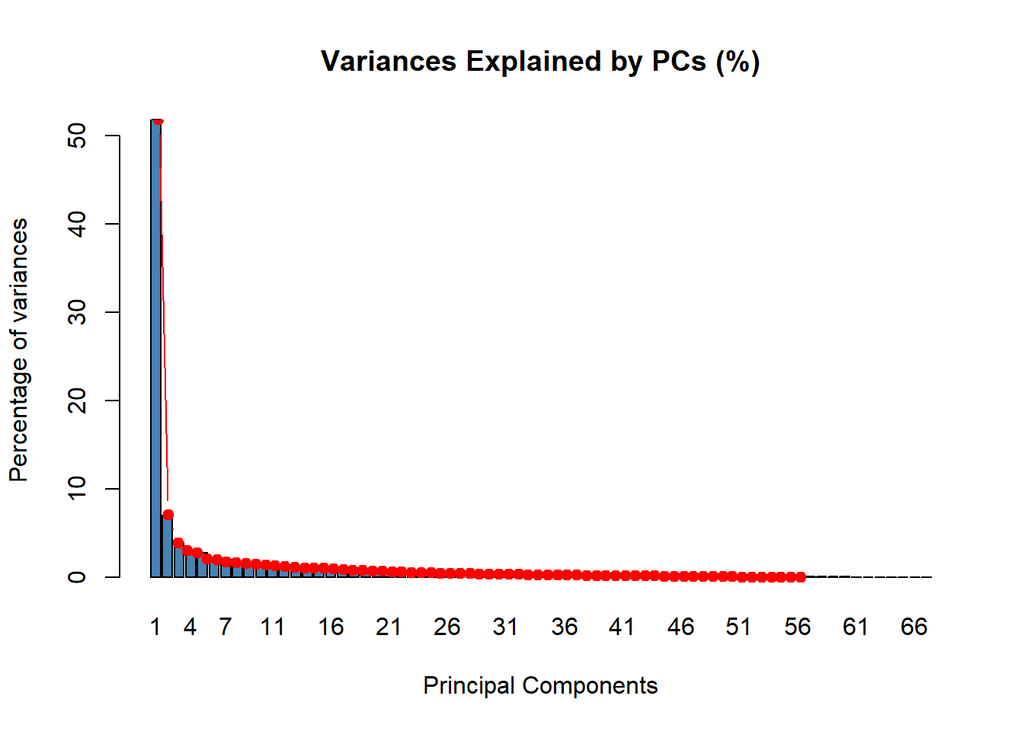

```r
library(FactoMineR)
predictors.pca <- PCA(predictors,ncp=63, graph = FALSE)
eig.val <- predictors.pca$eig
barplot(eig.val[, 2],
        names.arg = 1:nrow(eig.val),
        main = "Variances Explained by PCs (%)",
        xlab = "Principal Components",
        ylab = "Percentage of variances",
        col ="steelblue")
# Add connected line segments to the plot
lines(x = 1:nrow(eig.val), eig.val[, 2],
      type = "b", pch = 19, col = "red")
```

```r
predictors.pca.ind<-predictors.pca$ind$coord
pca.target<-data.frame(predictors.pca.ind, target)
```

It’s linear regression time.

```r
library(caret,quietly = T)
div_part_1 <- createDataPartition(y = pca.target$target, p = 0.7, list = F)
train_1 <- pca.target[div_part_1,]
test_1 <- pca.target[-div_part_1,]

my_very_first_linear_model<-lm(target~., data=train_1)

predicted_thingy=predict(my_very_first_linear_model, test_1[,!(names(test_1) %in% c("target"))])
real_thingy=test_1$target
testing=data.frame(real_thingy, predicted_thingy)
testing$meansquare=(testing$real_thingy-testing$predicted_thingy)^2
MSE1<-sum(testing$meansquare)/length(real_thingy)
MSE1
```

```
## [1] 0.01321485
```

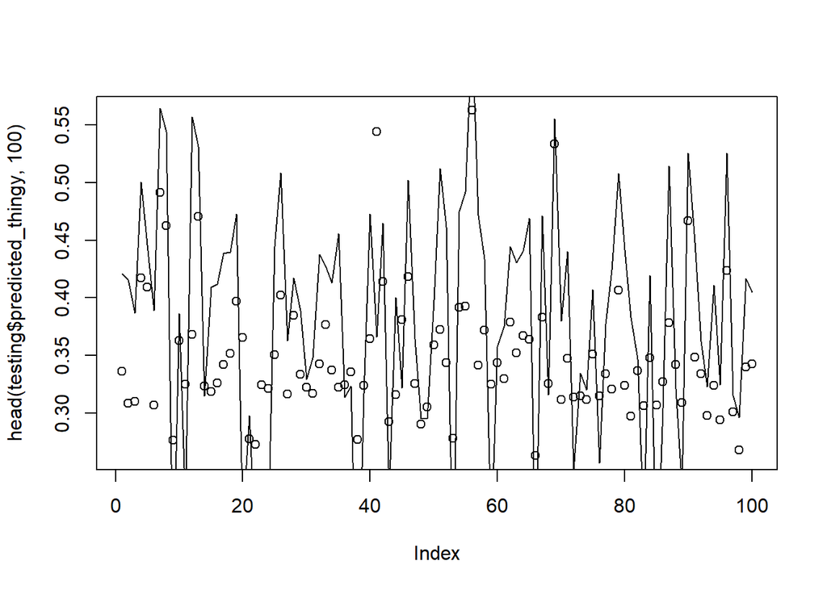

```r
plot(head(testing$predicted_thingy, 100))
lines(head(testing$real_thingy,100))
```

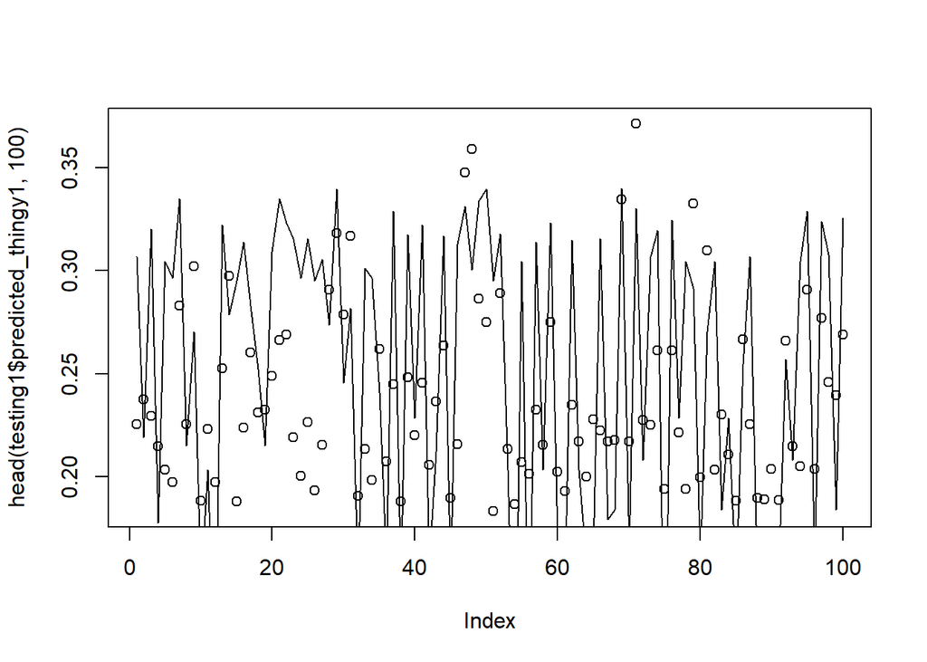

```r
clustering_target<-kmeans(target, centers = 2)

cluster1<-target[clustering_target$cluster==1]
cluster2<-target[clustering_target$cluster==2]

predictors1<-predictors.pca.ind[clustering_target$cluster==1,]
predictors2<-predictors.pca.ind[clustering_target$cluster==2,]

pca.target1<-data.frame(predictors1, cluster1)
pca.target2<-data.frame(predictors2, cluster2)

div_part_2_1 <- createDataPartition(y = pca.target1$cluster1, p = 0.7, list = F)
div_part_2_2 <- createDataPartition(y = pca.target2$cluster2, p = 0.7, list = F)

train_2_1 <- pca.target1[div_part_2_1,]
test_2_1 <- pca.target1[-div_part_2_1,]

train_2_2 <- pca.target2[div_part_2_2,]
test_2_2 <- pca.target2[-div_part_2_2,]

my_very_first_linear_model1<-lm(cluster1~., data=train_2_1)
my_very_first_linear_model2<-lm(cluster2~., data=train_2_2)

predicted_thingy1=predict(my_very_first_linear_model1, test_2_1[,!(names(test_2_1) %in% c("cluster1"))])
predicted_thingy2=predict(my_very_first_linear_model2, test_2_2[,!(names(test_2_2) %in% c("cluster2"))])
real_thingy1=test_2_1$cluster1
real_thingy2=test_2_2$cluster2
testing1=data.frame(real_thingy1, predicted_thingy1)
testing2=data.frame(real_thingy2, predicted_thingy2)
testing1$meansquare=(testing1$real_thingy1-testing1$predicted_thingy1)^2
testing2$meansquare=(testing2$real_thingy2-testing2$predicted_thingy2)^2
MSE2<-(sum(testing2$meansquare)+sum(testing1$meansquare))/(nrow(test_2_1)+nrow(test_2_2))

plot(head(testing1$predicted_thingy1, 100))
lines(head(testing1$real_thingy1,100))
```

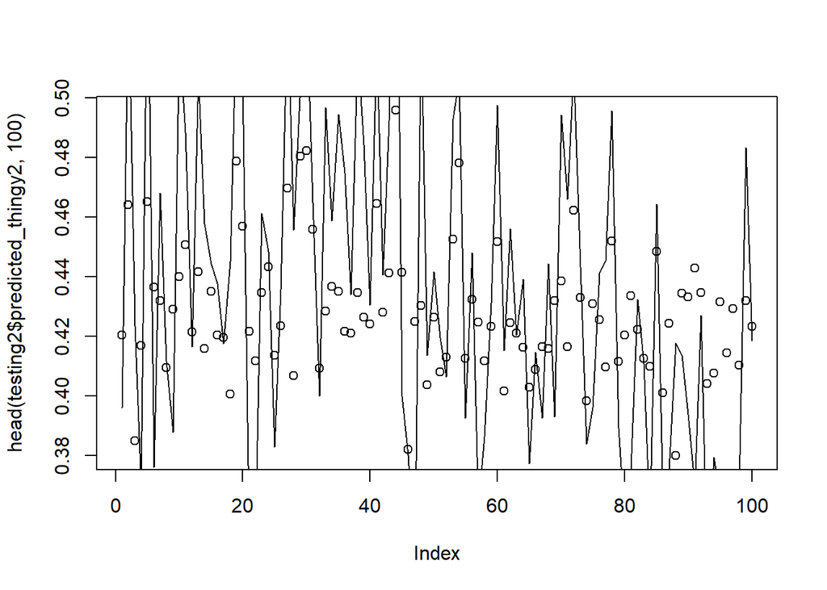

```r
plot(head(testing2$predicted_thingy2, 100))
lines(head(testing2$real_thingy2,100))
```

```r
clustering_target2<-kmeans(predictors.pca.ind, centers = 3)
cluster2<-target[clustering_target2$cluster==2]
cluster1<-target[clustering_target2$cluster==1]
cluster3<-target[clustering_target2$cluster==3]

predictors3<-predictors.pca.ind[clustering_target2$cluster==3,]
predictors2<-predictors.pca.ind[clustering_target2$cluster==2,]
predictors1<-predictors.pca.ind[clustering_target2$cluster==1,]

pca.target1<-data.frame(predictors1, cluster1)
pca.target2<-data.frame(predictors2, cluster2)
pca.target3<-data.frame(predictors3, cluster3)


div_part_3_1 <- createDataPartition(y = pca.target1$cluster1, p = 0.7, list = F)
div_part_3_2 <- createDataPartition(y = pca.target2$cluster2, p = 0.7, list = F)
div_part_3_3 <- createDataPartition(y = pca.target3$cluster3, p = 0.7, list = F)

train_3_1 <- pca.target1[div_part_3_1,]
test_3_1 <- pca.target1[-div_part_3_1,]

train_3_2 <- pca.target2[div_part_3_2,]
test_3_2 <- pca.target2[-div_part_3_2,]

train_3_3 <- pca.target3[div_part_3_3,]
test_3_3 <- pca.target3[-div_part_3_3,]

my_very_first_linear_model1<-lm(cluster1~., data=pca.target1)
my_very_first_linear_model2<-lm(cluster2~., data=pca.target2)
my_very_first_linear_model3<-lm(cluster3~., data=pca.target3)

predicted_thingy1=predict(my_very_first_linear_model1, test_3_1[,!(names(test_3_1) %in% c("cluster1"))])
predicted_thingy2=predict(my_very_first_linear_model2, test_3_2[,!(names(test_3_2) %in% c("cluster2"))])
```

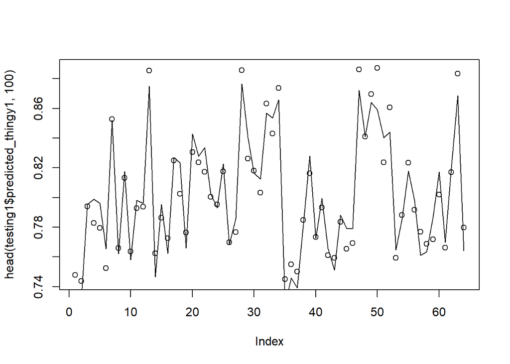

```r
predicted_thingy3=predict(my_very_first_linear_model3, test_3_3[,!(names(test_3_3) %in% c("cluster3"))])

real_thingy1=test_3_1$cluster1
real_thingy2=test_3_2$cluster2
real_thingy3=test_3_3$cluster3

testing1=data.frame(real_thingy1, predicted_thingy1)
testing2=data.frame(real_thingy2, predicted_thingy2)
testing3=data.frame(real_thingy3, predicted_thingy3)

testing1$meansquare=(testing1$real_thingy1-testing1$predicted_thingy1)^2
testing2$meansquare=(testing2$real_thingy2-testing2$predicted_thingy2)^2
testing3$meansquare=(testing3$real_thingy3-testing3$predicted_thingy3)^2
MSE3<-(sum(testing1$meansquare)+sum(testing2$meansquare)+sum(testing3$meansquare))/(nrow(testing1)+nrow(testing2)+nrow(testing3))

plot(head(testing1$predicted_thingy1, 100))
lines(head(testing1$real_thingy1,100))
```

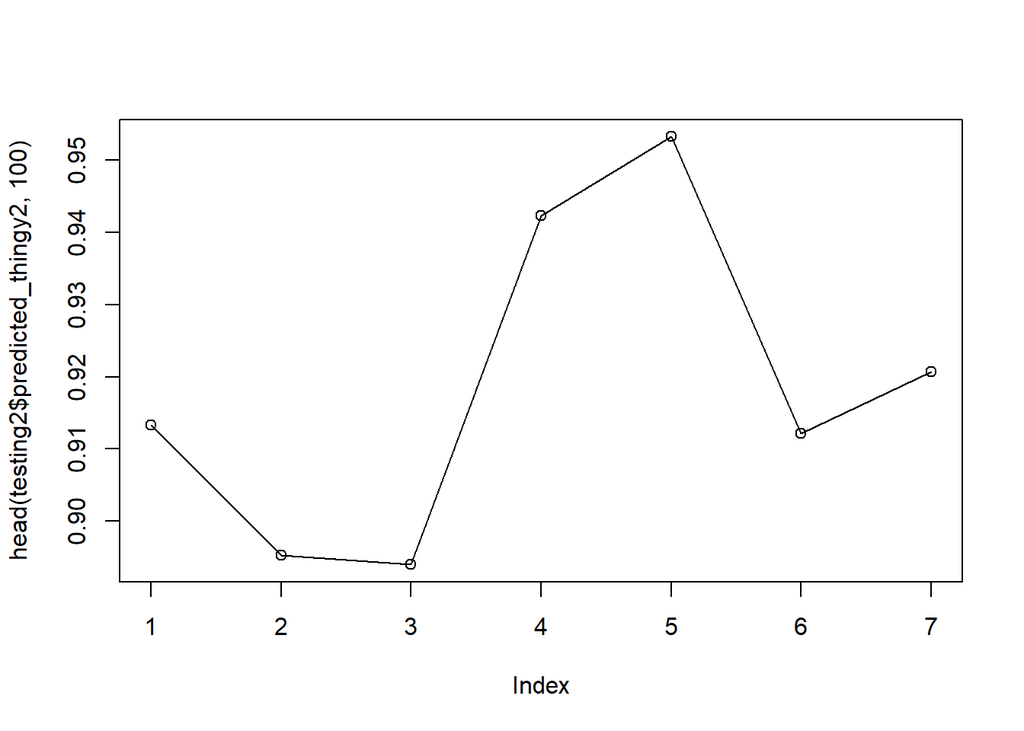

```r
plot(head(testing2$predicted_thingy2, 100))
lines(head(testing2$real_thingy2,100))
```

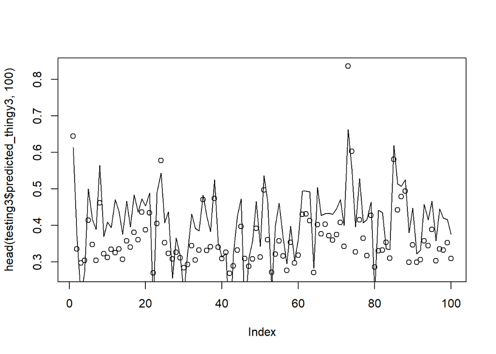

```r
plot(head(testing3$predicted_thingy3, 100))
lines(head(testing3$real_thingy3,100))
```

```r
MSE1
```

```
## [1] 0.01321485
```

```r
MSE2
```

```
## [1] 0.004394137
```

```r
MSE3
```

```
## [1] 0.007756718
```

We’ll also play with stepAIC here to get the best out of all the universes of our variables

```r
library(MASS)
my_funniest_step_aic<-stepAIC(my_very_first_linear_model)
```

```
## Start:  AIC=-95103.41
## target ~ Dim.1 + Dim.2 + Dim.3 + Dim.4 + Dim.5 + Dim.6 + Dim.7 +
##     Dim.8 + Dim.9 + Dim.10 + Dim.11 + Dim.12 + Dim.13 + Dim.14 +
##     Dim.15 + Dim.16 + Dim.17 + Dim.18 + Dim.19 + Dim.20 + Dim.21 +
##     Dim.22 + Dim.23 + Dim.24 + Dim.25 + Dim.26 + Dim.27 + Dim.28 +
##     Dim.29 + Dim.30 + Dim.31 + Dim.32 + Dim.33 + Dim.34 + Dim.35 +
##     Dim.36 + Dim.37 + Dim.38 + Dim.39 + Dim.40 + Dim.41 + Dim.42 +
##     Dim.43 + Dim.44 + Dim.45 + Dim.46 + Dim.47 + Dim.48 + Dim.49 +
##     Dim.50 + Dim.51 + Dim.52 + Dim.53 + Dim.54 + Dim.55 + Dim.56 +
##     Dim.57 + Dim.58 + Dim.59 + Dim.60 + Dim.61 + Dim.62 + Dim.63
##
##          Df Sum of Sq    RSS    AIC
## - Dim.18  1     0.003 197.67 -95105
## - Dim.17  1     0.004 197.67 -95105
## - Dim.46  1     0.005 197.68 -95105
## - Dim.7   1     0.007 197.68 -95105
## - Dim.61  1     0.010 197.68 -95104
## - Dim.32  1     0.017 197.69 -95104
## <none>                197.67 -95103
## - Dim.14  1     0.019 197.69 -95103
## - Dim.13  1     0.028 197.70 -95102
## - Dim.58  1     0.033 197.70 -95102
## - Dim.49  1     0.037 197.71 -95102
## - Dim.51  1     0.038 197.71 -95101
## - Dim.56  1     0.042 197.71 -95101
## - Dim.27  1     0.044 197.71 -95101
## - Dim.31  1     0.050 197.72 -95100
## - Dim.39  1     0.083 197.75 -95097
## - Dim.15  1     0.084 197.75 -95097
## - Dim.36  1     0.105 197.78 -95094
## - Dim.30  1     0.112 197.78 -95094
## - Dim.53  1     0.116 197.79 -95093
## - Dim.63  1     0.126 197.80 -95092
## - Dim.16  1     0.136 197.81 -95091
## - Dim.29  1     0.137 197.81 -95091
## - Dim.26  1     0.145 197.81 -95090
## - Dim.24  1     0.162 197.83 -95089
## - Dim.43  1     0.249 197.92 -95080
## - Dim.54  1     0.251 197.92 -95079
## - Dim.19  1     0.352 198.02 -95069
```

[output cut: 391 more lines]

```
## - Dim.37  1     1.523 199.22 -94955
## - Dim.40  1     1.559 199.26 -94951
## - Dim.28  1     1.795 199.50 -94927
## - Dim.9   1     2.724 200.43 -94831
## - Dim.35  1     2.912 200.61 -94812
## - Dim.52  1     3.980 201.68 -94703
## - Dim.10  1     4.340 202.04 -94667
## - Dim.48  1     4.471 202.17 -94653
## - Dim.44  1     4.812 202.51 -94619
## - Dim.21  1     5.389 203.09 -94560
## - Dim.5   1     8.118 205.82 -94287
## - Dim.4   1     8.461 206.16 -94253
## - Dim.6   1     9.656 207.36 -94134
## - Dim.2   1    19.621 217.32 -93171
## - Dim.1   1    50.929 248.63 -90410
```

```r
formula<-target ~ Dim.1 + Dim.2 + Dim.3 + Dim.4 + Dim.5 + Dim.6 + Dim.7 +
  Dim.8 + Dim.9 + Dim.10 + Dim.11 + Dim.13 + Dim.16 + Dim.17 +
  Dim.19 + Dim.20 + Dim.21 + Dim.22 + Dim.23 + Dim.25 + Dim.27 +
  Dim.28 + Dim.30 + Dim.31 + Dim.33 + Dim.34 + Dim.35 + Dim.36 +
  Dim.37 + Dim.38 + Dim.39 + Dim.40 + Dim.41 + Dim.42 + Dim.43 +
  Dim.44 + Dim.45 + Dim.46 + Dim.47 + Dim.48 + Dim.49 + Dim.50 +
  Dim.51 + Dim.52 + Dim.53 + Dim.54 + Dim.55 + Dim.57 + Dim.58 +
  Dim.59 + Dim.60 + Dim.61 + Dim.62

my_second_linear_model_yay<-lm(formula, data=train_1)

predicted_thingy=predict(my_second_linear_model_yay, test_1[,!(names(test_1) %in% c("target"))])
real_thingy=test_1$target
testing=data.frame(real_thingy, predicted_thingy)
testing$meansquare=(testing$real_thingy-testing$predicted_thingy)^2
MSE1_1<-sum(testing$meansquare)/length(real_thingy)
MSE1_1
```

```
## [1] 0.01302267
```

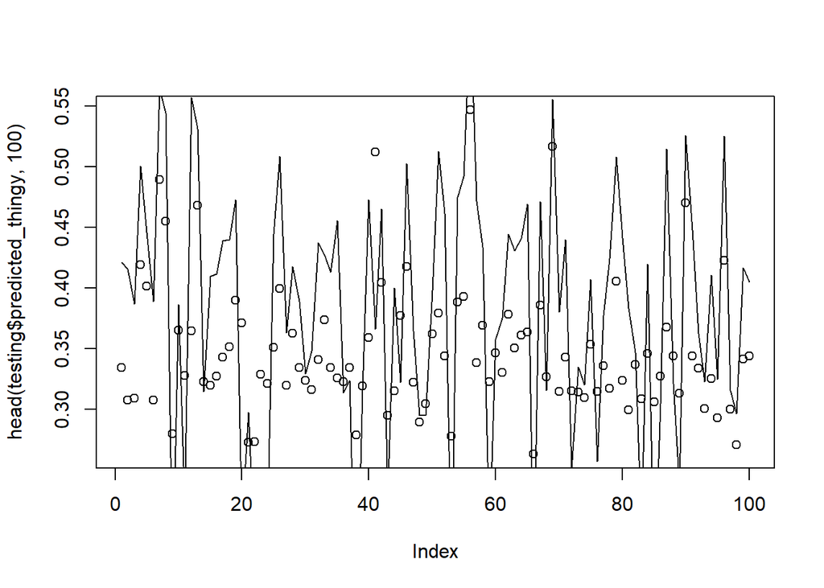

```r
plot(head(testing$predicted_thingy, 100))
lines(head(testing$real_thingy,100))
```